# ABAR: Chapter 3

We can make this more explicit by adding a new variable to indicate if a sale price is above average. We can then tell `ggparcood` to group by this new variable. Now we clearly see that above average sale prices are related to much newer homes.

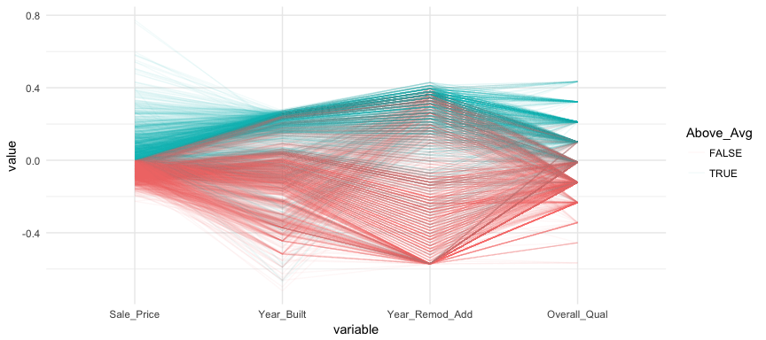

```r
ames %>%
  select(variables) %>%
  mutate(Above_Avg = Sale_Price > mean(Sale_Price)) %>%
  ggparcoord(
    alpha = .05,
    scale = "center",
    columns = 1:4,
    groupColumn = "Above_Avg"
    )
```

Mosaic plots are a graphical method for visualizing data from two or more qualitative variables. In this visual the graphics area is divided up into rectangles proportional in size to the counts of the combinations they represent.

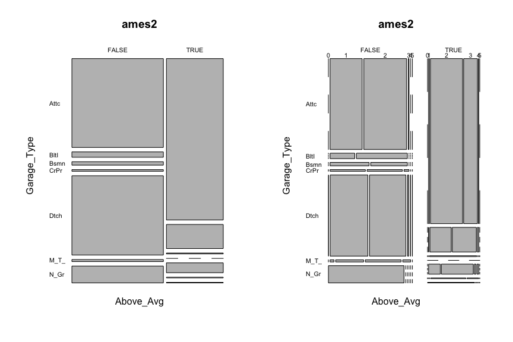

```r
ames2 <- ames %>%
  mutate(
    Above_Avg = Sale_Price > mean(Sale_Price),
    Garage_Type = abbreviate(Garage_Type),
    Garage_Qual = abbreviate(Garage_Qual)
         )

par(mfrow = c(1, 2))
mosaicplot(Above_Avg ~ Garage_Type, data = ames2, las = 1)
mosaicplot(Above_Avg ~ Garage_Type + Garage_Cars, data = ames2, las = 1)
```

Treemaps are also a useful visualization aimed at assessing the hierarchical structure of data. Treemaps are primarily used to assess a numeric value across multiple categories. It can be useful to assess the counts or porportions of a categorical variable nested within other categorical variables. For example, we can use a treemap to visualize the above right mosaic plot that illustrates the number of homes sold above and below average sales price with different garage characteristics. We can see in the treemap that houses with above average prices tend to have attached 2 and 3-car garages. Houses sold below average price have more attached 1-car garages and also have far more detached garages.

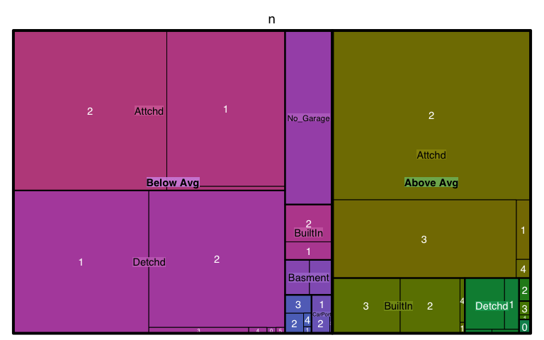

```r
ames %>%
  mutate(Above_Below = ifelse(Sale_Price > mean(Sale_Price), "Above Avg", "Below Avg")) %>%
  count(Garage_Type, Garage_Cars, Above_Below) %>%
  treemap(
    index = c("Above_Below", "Garage_Type", "Garage_Cars"),
    vSize = "n"
  )
```

A heatmap is a graphical display of numerical data where color is used to denote the case value realtive to other values in the column. Heatmaps can be extremely useful in identify clusters of strongly correlated values. We can select all numeric variables in our `ames` data set, compute the correlation matrix and visualize this matrix with a heatmap. Those locations with dark red represent correlations with smaller values while lighter colored cells represent larger values. Looking at `Sale_Price` (3rd row from top) you can see that the smaller values are clustered to the left of the plot suggestion weaker linear relationships with variables such as `BsmtFin_Sf_1`, `Bsmt_Unf_SF`, `Longitude`, `Enclosed_Porch`, etc. The larger correlations values for `Sale_Price` align with variables to the right of the plot such as `Garage_Cars`, `Garage_Area`, `First_Flr_SF`, etc.

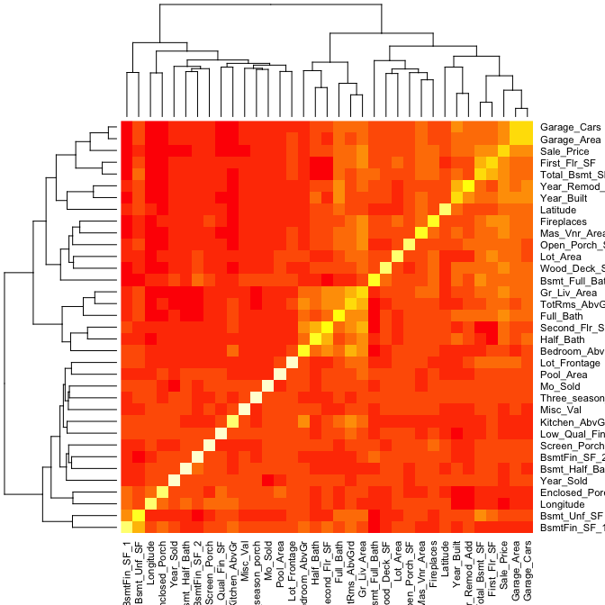

```r
ames %>%
  select_if(is.numeric) %>%
  cor() %>%
  heatmap()
```

A heatmap is a great way to assess the relationship across a large data set. However, when you are dealing with a smaller data set (or subset), you may want to create a matrix plot to compare relationships across all variables. For example, here I select `Sale_Price` and all variables that contain “sf” (all square footage variables), I scale all variables, and then visualize the scatter plot and correlation values with `GGally::ggpairs`.

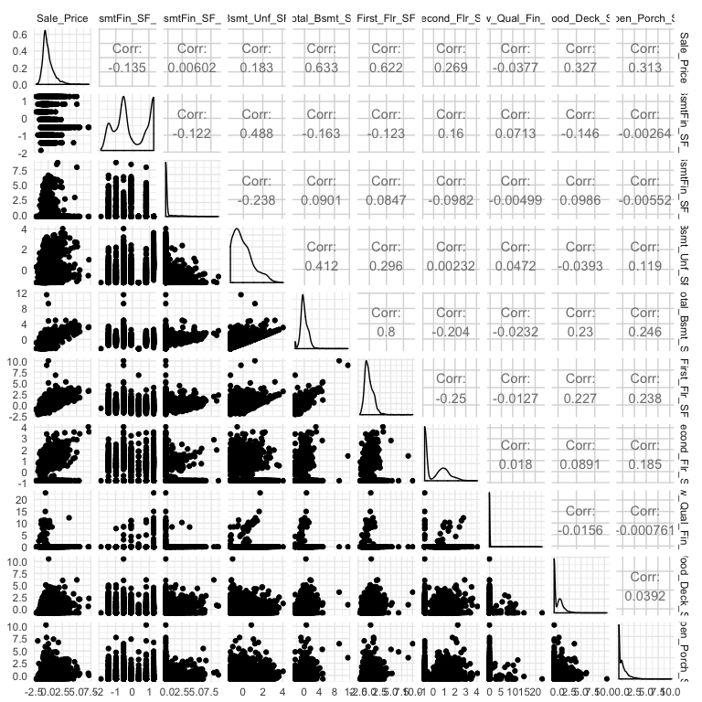

```r
ames %>%
  select(Sale_Price, contains("sf")) %>%
  map_df(scale) %>%
  ggpairs()
```

# Data Quality

Graphical displays can also assist in summarizing certain data quality features. In the previous sections we illustrated how we can identify outliers but missing data also represent an important characteristic of our data. This chapter has been using the processed version of the Ames housing data set. However, if we use the raw data we see that there are 13,997 missing values. It is important to understand how these missing values are dispersed acrossed a data set as that can determine if you need to eliminate a variable or if you can impute.

```r
sum(is.na(AmesHousing::ames_raw))
```

```
## [1] 13997
```

Heatmaps have a nice alternative use case for visualizing missing values across a data set. In this example `is.na(AmesHousing::ames_raw)` will return a Boolean (TRUE/FALSE) output indicating the location of missing values and by multiplying this value by 1 converts the output to 0/1 binary to be plotted. All yellow locations in our heatmap represent missing values. This allows us to see those variables where the majority of the observations have missing values (i.e. `Alley`, `Fireplace Qual`, `Pool QC`, `Fence`, and `Misc Feature`). Due to their high frequency of missingness, these variables would likely need to be removed from future analytic approaches. However, we can also spot other unique features of missingness. For example, missing values appear to occur across all garage variables for the same observations.

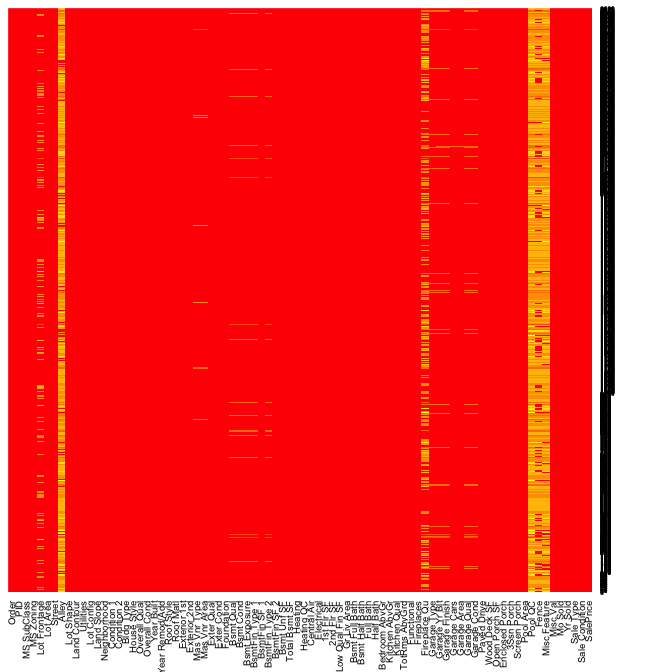

```r
heatmap(1 * is.na(AmesHousing::ames_raw), Rowv = NA, Colv = NA)
```

If we dig a little deeper into these variables we would notice that `Garage Cars` and `Garage Area` all contain the value 0 for every observation where the other `Garage_xx` variables have missing values. This is because in the raw Ames housing data set, they did not have an option to identify houses with no garages. Therefore, all houses with no garage were identified by including nothing. This would be opportunity to create a new categorical level (“None”) for these garage variables.

```r
AmesHousing::ames_raw %>%
  filter(is.na(`Garage Type`)) %>%
  select(contains("garage"))
```

```
## # A tibble: 157 x 7
##    `Garage Type` `Garage Yr Blt` `Garage Finish` `Gara… `Gara… `Gar… `Gar…
##    <chr>                   <int> <chr>            <int>  <int> <chr> <chr>
##  1 <NA>                       NA <NA>                 0      0 <NA>  <NA>
##  2 <NA>                       NA <NA>                 0      0 <NA>  <NA>
##  3 <NA>                       NA <NA>                 0      0 <NA>  <NA>
##  4 <NA>                       NA <NA>                 0      0 <NA>  <NA>
##  5 <NA>                       NA <NA>                 0      0 <NA>  <NA>
##  6 <NA>                       NA <NA>                 0      0 <NA>  <NA>
##  7 <NA>                       NA <NA>                 0      0 <NA>  <NA>
##  8 <NA>                       NA <NA>                 0      0 <NA>  <NA>
##  9 <NA>                       NA <NA>                 0      0 <NA>  <NA>
## 10 <NA>                       NA <NA>                 0      0 <NA>  <NA>
## # ... with 147 more rows
```

An alternative approach is to use `extracat::visna`, which allows us to visualize missing patters. The columns represent the 82 variables and the rows the missing patterns. The cells for the variables with missing values in a pattern are drawn in blue. The variables and patterns have been ordered by numbers of missings on both rows and columns (`sort = "b"`). The bars beneath the columns show the proporations of missings by variable and the bars on the right show the relative frequencies of patterns.

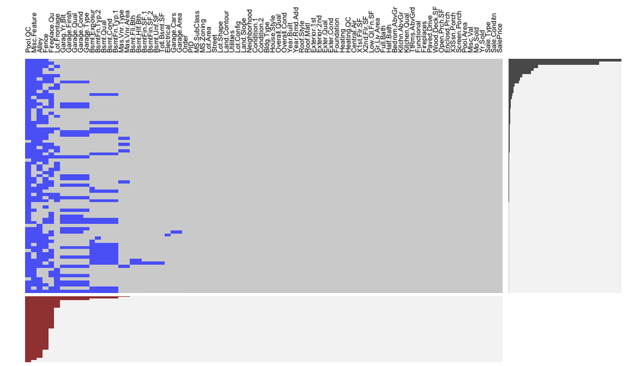

```r
extracat::visna(AmesHousing::ames_raw, sort = "b")
```

Data can be missing for different reasons. It could be that a value was not recorded, or that it was, but was obviously an error. As in our case with the garage variables it could be because there was not an option to record the specific value observed so the default action was to not record any value. Regardless, it is important to identify and understand how missing values are observed across a data set as they can provide insight into how to deal with these observations.

# Exercises

[^1]: We could also use `hist(ames$Sale_Price)` to produce a histogram with base R graphics.
[^2]: These are approximates because the binning will round to whole numbers (12,800 rather than 12,370.)
[^3]: Two things to note here. 1. If you want to change the binwidth you either need to feed a log tranformed number to binwidth or, as I did, increase the bins by using `bins = 100`. 2. If you have values of zero in your variable try `scale_x_continuous(trans = “log1p”), which adds 1 prior to the log transformation.
[^4]: A great resource to learn more about which you can learn more about managing factors is R for Data Science, Ch. 15.